# predict_rest_tremor_presence_UPDRS_3_17_score

```python
import pandas as pd
import numpy as np
import os
from tqdm import tqdm
from DataStructureGenerator import DataStructureGenerator
import matplotlib.pyplot as plt
import seaborn as sns
from sklearn.model_selection import train_test_split
from sklearn.metrics import confusion_matrix, classification_report
import copy
from sklearn import metrics
from sklearn.metrics import ConfusionMatrixDisplay
from sklearn.metrics import accuracy_score
from sklearn.ensemble import RandomForestClassifier
from sklearn.linear_model import LogisticRegression
from sklearn.model_selection import LeaveOneGroupOut
from sklearn.preprocessing import StandardScaler
```

**1. Data collection**

```python
base_path = r"C:\FDS\Parkinson"
clinic_folder = "Clinic_Data_PD-BioStampRC21"
activity_folder = "FullDataSet_PD-BioStampRC21"

dataGenerator2 = DataStructureGenerator(base_path, clinic_folder, activity_folder)
list_events = ['UPDRS 3.17 - Rest Tremor Amplitude']
all_data_one_event = dataGenerator2.generate_data_structure(list_events)
```

```python
def check_timestamp_irregularities(timestamps):
    # Calculate differences between consecutive timestamps
    time_diffs = np.diff(timestamps)

    # Check if the differences are consistent (e.g., within a small tolerance)
    tolerance = 0.1 * np.mean(time_diffs)  # 10% of the mean difference
    irregularities = np.abs(time_diffs - np.mean(time_diffs)) > tolerance

    if np.any(irregularities):
        # print(f"Irregularities found in timestamps: {time_diffs[irregularities]}")
        return True
    else:
        # print("No irregularities found in timestamps.")
        return False
```

```python
# 1.1 Gravity Compensation
from scipy.signal import butter, filtfilt

# remove low-frequency components (like gravity) from an accelerometer signal — using a high-pass filter.
# cutoff=0.5: Because human motion (tremor, posture, walking) typically happens above 0.5 Hz
def remove_gravity(accel_series, fs, cutoff=0.5):

    if len(accel_series) < 16:
        # print(f"Skipping gravity removal: only {len(accel_series)} samples")
        return accel_series

    # Filter order=4: Controls steepness of the cutoff
    # cutoff/fs/2: Normalized cutoff for filter
    # 'highpass': Remove frequencies below cutoff Hz, keeps only motion-related signal
    # b, a are filter coefficients (arrays), used for filtering
    b, a = butter(4, cutoff/(fs/2), 'highpass')

    # applies the filter forward and backward to prevent phase shift
    # Filters out slow-changing components like gravity (≈0 Hz).
    # Keeps higher-frequency components → usually real motion (e.g., hand tremor)
    return filtfilt(b, a, accel_series)

# calculate window samples for each set of signal
# desired_time_ms = 250 to retain full tremor details
def get_rolling_window(signal, fs, desired_time_ms=250, min_window=3):
    N = len(signal)
    desired_time_sec = desired_time_ms / 1000
    win = int(fs * desired_time_sec)
    return min(N, max(min_window, win))

# 1.2 Noise Reduction
def denoise(data, window):
    # Remove spike by median value of range window items where the spike is the middle value
    # return data.rolling(window=window, center=True).median()
    data.rolling(window=window, center=True, min_periods=1).median()
    # df_sensor['Accel_X_no_gravity'].rolling(window=window, center=True, min_periods=1).median()

def gravity_denoise(input_data):

    # Create a fully independent dictionary to return
    new_dic = {}

    # output_dic = copy.deepcopy(input_data)
    for participant_id, participant_data in input_data.items():

        new_participant_data = {}
        # Deep copy the DataFrame in 'activity'
        new_activity_df = participant_data['activity'].copy(deep=True)

        new_sensor_data_list = []

        for index, row in new_activity_df.iterrows():
            # df_sensor = pd.DataFrame()
            # Copy each sensor data entry
            sensor_data_list = []
            for sensor in row['sensor data']:
                # df_sensor = sensor['sensor data'].copy(deep=True)
                df_sensor = sensor['sensor data']
                if isinstance(df_sensor, pd.DataFrame):

                    df_sensor = df_sensor.copy(deep=True)

                    # calculate sampling frequency
                    timestamps = df_sensor['Timestamp (ms)'].values

                    # Check for irregularities
                    if check_timestamp_irregularities(timestamps):
                        print(f"Skipping participant {participant_id} due to irregular timestamps.")
                        continue

                    fs = 1000 / np.mean(np.diff(timestamps))  # because timestamps are in milliseconds

                    for axis in ['X','Y','Z']:
                        # remove gravity from the signal
                        df_sensor[f'Accel_{axis}_no_gravity'] = remove_gravity(df_sensor[f'Accel {axis} (g)'], fs)

                        # denoise the signal
                        window = get_rolling_window(df_sensor[f'Accel_{axis}_no_gravity'], fs)
                        # df_sensor[f'Accel_{axis}_clean'] = denoise(df_sensor[f'Accel_{axis}_no_gravity'], window)
                        df_sensor[f'Accel_{axis}_clean']= df_sensor[f'Accel_{axis}_no_gravity'].rolling(window=window, center=True, min_periods=1).median()

                    # sensor_data_list.append({'sensor data': df_sensor})
                    sensor_data_list.append({
                    'sensor name': sensor['sensor name'],   # carry over the original sensor name
                    'sensor data': df_sensor
                    })

            # Assign the new sensor data list back to row
            new_activity_df.at[index, 'sensor data'] = sensor_data_list

        # Store updated activity back to participant
        new_participant_data['activity'] = new_activity_df
        new_participant_data['clinical'] = participant_data['clinical']
        new_dic[participant_id] = new_participant_data
                    # # Update back to dictionary
                    # sensor['sensor data'] = df_sensor
    return new_dic

# count missing values in the dataset
def count_missing_values(input_dic):
    total_missing = 0
    total_values = 0
    for participant_id, participant_data in input_dic.items():
        for index, row in participant_data['activity'].iterrows():
            for sensor in row['sensor data']:
                df_sensor = sensor['sensor data']
                if isinstance(df_sensor, pd.DataFrame):
                    total_missing += df_sensor.isna().sum().sum()
                    total_values += df_sensor.size  # total cells = rows × columns

    missing_ratio = total_missing / total_values if total_values > 0 else 0

    print(f"Total values: {total_values}")
    print(f"Missing values: {total_missing}")
    print(f"Missing ratio: {missing_ratio:.1%}")
    return total_missing

def handleMissing(input_dic):
    for participant_id, participant_data in input_dic.items():
        for index, row in participant_data['activity'].iterrows():
            # df_sensor = pd.DataFrame()
            for sensor in row['sensor data']:
                df_sensor = sensor['sensor data']
                if isinstance(df_sensor, pd.DataFrame):
                    # Apply to numeric columns only
                    # Select only numeric columns excluding 'Timestamp'
                    numeric_cols = df_sensor.select_dtypes(include='number').columns
                    numeric_cols = [col for col in numeric_cols if 'time' not in col.lower()]  # exclude 'Timestamp'

                    df_sensor[numeric_cols] = df_sensor[numeric_cols].interpolate().fillna(method='bfill').fillna(method='ffill')

                    # Update back to dictionary
                    sensor['sensor data'] = df_sensor
    return input_dic
```

```python
# Signal Magnitude Vector (SMV)
def calculate_smv(df):
    return np.sqrt(df['Accel_X_clean']**2 + df['Accel_Y_clean']**2 + df['Accel_Z_clean']**2)

def compute_smv(input_dic):
    for participant_id, participant_data in input_dic.items():
        for index, row in participant_data['activity'].iterrows():
            df_sensor = pd.DataFrame()
            for sensor in row['sensor data']:
                df_sensor = sensor['sensor data']
                df_sensor['SMV'] = calculate_smv(df_sensor)
    return input_dic
```

```python
import numpy as np
from scipy.signal import welch
from scipy.fft import fft, fftfreq
import antropy as ant

# This gives how much energy lies in the tremor frequency band.
def compute_relative_power(signal, fs, band=(3, 10)):
    try:
        if len(signal) < 16:
            return 0.0  # fallback for tiny windows
        f, Pxx = welch(signal, fs=fs, nperseg=min(64, len(signal)))
        total_power = np.sum(Pxx)
        band_power = np.sum(Pxx[(f >= band[0]) & (f <= band[1])])
        return band_power / total_power if total_power > 0 else 0.0
    except:
        return 0.0

# This counts how often the signal crosses zero, calculated based on product of two consecutive values is negative
def compute_zero_crossing_rate(signal):
    signal = np.asarray(signal)  # Convert list to NumPy array
    # return ((signal[:-1] * signal[1:]) < 0).sum() / max(len(signal), 1)
    return ((signal[:-1] * signal[1:]) < 0).sum() / max(len(signal) - 1, 1)

# Measures complexity/irregularity of a signal.
def compute_sample_entropy(signal):
    try:
        if np.isnan(signal).any() or np.isinf(signal).any():
            raise ValueError("Signal contains NaN or inf values.")
        entropy = ant.sample_entropy(signal) if len(signal) >= 10 else 0.0
        if np.isnan(entropy) or np.isinf(entropy):
            # print("Entropy is NaN or inf, returning 0.0")
            # print("len of signal:", len(signal))
            return 0.0
        return entropy
    except:
        return 0.0

# dominant_freq: dominant frequency in the 3–10 Hz range.
# dominant_power: the strength/amplitude of that frequency component
# fs : samples per second
def compute_fft_peak(signal, fs):

    # Convert to NumPy array
    signal = np.asarray(signal)
    if len(signal) < 8:
        return 0.0, 0.0  # fallback

    yf = np.abs(fft(signal))

    # Get frequency values
    xf = fftfreq(len(signal), 1/fs)

    # Keep only positive frequencies
    pos_mask = xf > 0
    xf = xf[pos_mask]
    yf = yf[pos_mask]

    # Keep 3–10 Hz (tremor band)
    tremor_mask = (xf >= 3) & (xf <= 10)

    if not np.any(tremor_mask):
        return 0.0, 0.0

    dominant_freq = xf[tremor_mask][np.argmax(yf[tremor_mask])]
    dominant_power = np.max(yf[tremor_mask])
    return dominant_freq, dominant_power
```

```python
def countMissingDf(df):
    # Count missing values in the DataFrame
    total_missing = df.isna().sum().sum()
    missing_col = df.isna().sum()
    total_values = df.size  # total cells = rows × columns
    missing_ratio = total_missing / total_values if total_values > 0 else 0
    print(f"Data size: {df.shape}")
    print(f"Total values: {total_values}")
    print(f"Missing values: {total_missing}")
    print(f"Missing ratio: {missing_ratio:.1%}")
    if total_missing > 0:
        print(f"Columns have missing values:\n{missing_col[missing_col > 0]}")

    # return total_missing, missing_ratio, total_values
```

```python
def extract_features(signal, fs):
    centered = signal - np.mean(signal)
    freq, power = compute_fft_peak(centered, fs)

    return {
        'mean': np.mean(centered),
        'std': np.std(centered),
        'ptp': np.ptp(centered),
        'zcr': compute_zero_crossing_rate(centered),
        'rel_power': compute_relative_power(centered, fs),
        'sample_entropy': compute_sample_entropy(centered),
        'tremor_freq': freq,
        'tremor_power': power
    }
```

```python
def buildTremorDataSetForOneEvent(dataAllParticipants):
    # Initialize an empty list to store the data
    data_for_training = []
    my_list = ["ON", "OFF"]
    try :
        # access the event data for each participant
        for participant_id, participant_data in dataAllParticipants.items():
            clinic_data = participant_data['clinical']
            for index, row in participant_data['activity'].iterrows():

                medication = "None"
                side="Unknown"
                updrs_score = -1

                # Check if the column contains any of the values
                matches = sum(1 for value in my_list if value in row['activity attribute'])

                # Check the length of matching rows
                if matches > 1:
                    print(f"Number of matches: {matches}")

                # Check side and medication
                if "RUE" in row['activity attribute']:
                    side = "RUE"
                elif "LUE" in row['activity attribute']:
                    side = "LUE"
                elif "RLE" in row['activity attribute']:
                    side = "RLE"
                elif "LLE" in row['activity attribute']:
                    side = "LLE"

                if "ON" in row['activity attribute']:
                    medication = "ON"
                elif "OFF" in row['activity attribute']:
                    medication = "OFF"

                if side == "Unknown":
                    continue

                # Read UPDRS Score
                if side == "RUE":
                    if medication == "ON":
                        updrs_score = clinic_data['updrs_3_17b_on']
                    elif medication == "OFF":
                        updrs_score = clinic_data['updrs_3_17b_off']
                    else:
                        updrs_score = clinic_data['updrs_3_17b']
                elif side == "LUE":
                    if medication == "ON":
                        updrs_score = clinic_data['updrs_3_17a_on']
                    elif medication == "OFF":
                        updrs_score = clinic_data['updrs_3_17a_off']
                    else:
                        updrs_score = clinic_data['updrs_3_17a']
                elif side == "RLE":
                    if medication == "ON":
                        updrs_score = clinic_data['updrs_3_17c_on']
                    elif medication == "OFF":
                        updrs_score = clinic_data['updrs_3_17c_off']
                    else:
                        updrs_score = clinic_data['updrs_3_17c']
                elif side == "LLE":
                    if medication == "ON":
                        updrs_score = clinic_data['updrs_3_17d_on']
                    elif medication == "OFF":
                        updrs_score = clinic_data['updrs_3_17d_off']
                    else:
                        updrs_score = clinic_data['updrs_3_17d']

                # Read tremor data
                df_sensor = pd.DataFrame()
                for sensor in row['sensor data']:
                    df_sensor = sensor['sensor data']

                    # calculate sampling frequency
                    timestamps = df_sensor['Timestamp (ms)'].values
                    fs = 1000 / np.mean(np.diff(timestamps))  # because timestamps are in milliseconds

                    feats  = extract_features(df_sensor['SMV'], fs)

                    # Create a dictionary to store the data entry
                    data_entry = {
                        'participant id': participant_id,
                        'side': side,
                        'medication': medication,
                        'start timestamp (ms)': row['start timestamp (ms)'],
                        'stop timestamp (ms)': row['stop timestamp (ms)'],
                        'sensor data len': len(df_sensor),
                        'sensor name': sensor['sensor name'],
                        'tremor_std': feats['std'],
                        'tremor_ptp': feats['ptp'],
                        'tremor_zcr': feats['zcr'],
                        'tremor_rel_power': feats['rel_power'],
                        'tremor_sample_entropy': feats['sample_entropy'],
                        'tremor_freq': feats['tremor_freq'],
                        'tremor_power': feats['tremor_power'],
                        '3.17 UPDRS Score': updrs_score
                    }
                    data_for_training.append(data_entry)
    except Exception as e:
        print(f"An error occurred while processing participant {participant_id}: {e}")
    # Convert the list of data into a DataFrame
    return pd.DataFrame(data_for_training)
```

```python
def missingDictCheck(input_dic):
    # Count missing before
    print(f"Missing values statistics")
    missing_before = count_missing_values(input_dic)

    if missing_before > 0:
        # Apply imputation
        input_dic = handleMissing(input_dic)

        # Count missing after
        print(f"Missing values after processing")
        count_missing_values(input_dic)
    else:
        print("No missing values found. No imputation needed.")
    return input_dic
```

**2. Data Preprocessing**

```python
data_event_processed_missing = copy.deepcopy(all_data_one_event)

# Missing values check
data_event_processed_missing = missingDictCheck(data_event_processed_missing)
```

```
Missing values statistics
Total values: 9428
Missing values: 0
Missing ratio: 0.0%
No missing values found. No imputation needed.
```

```python
data_event_processed = copy.deepcopy(data_event_processed_missing)

# Remove gravity and denoise the signal
data_event_processed = gravity_denoise(data_event_processed)
```

**3. Feature engineering**

```python
# feature engineering
data_event_processed_smv = copy.deepcopy(data_event_processed)

# Calculate SMV for each sensor data
data_event_processed_smv = compute_smv(data_event_processed_smv)
```

```python
# Extract tremor features from sensor data: relative power, zero cossing rate, sample entrophy, amplitude, frequency, stand deviation, peak to peak amplitude
df_event = buildTremorDataSetForOneEvent(data_event_processed_smv)
```

```python
# take a look at the basic statictics of the dataset
df_event.describe()
```

|  | start timestamp (ms) | stop timestamp (ms) | sensor data len | tremor_std | tremor_ptp | tremor_zcr | tremor_rel_power | tremor_sample_entropy | tremor_freq | tremor_power | 3.17 UPDRS Score |
| --- | --- | --- | --- | --- | --- | --- | --- | --- | --- | --- | --- |
| count | 3.200000e+01 | 3.200000e+01 | 32.00000 | 32.000000 | 32.000000 | 32.000000 | 32.000000 | 32.000000 | 32.000000 | 32.000000 | 32.000000 |
| mean | 3.861854e+06 | 3.864214e+06 | 73.65625 | 0.009108 | 0.040819 | 0.175537 | 0.216046 | 1.160845 | 4.772311 | 0.092925 | 0.750000 |
| std | 3.751782e+06 | 3.751762e+06 | 68.83248 | 0.007470 | 0.038462 | 0.076236 | 0.148657 | 0.551124 | 1.458341 | 0.094880 | 0.718421 |
| min | 5.769420e+05 | 5.803090e+05 | 9.00000 | 0.001967 | 0.007333 | 0.061224 | 0.000000 | 0.000000 | 3.076753 | 0.012350 | 0.000000 |
| 25% | 8.913448e+05 | 8.939378e+05 | 39.75000 | 0.002919 | 0.011539 | 0.129934 | 0.108844 | 0.846466 | 3.449133 | 0.029492 | 0.000000 |
| 50% | 2.207629e+06 | 2.209640e+06 | 57.50000 | 0.004992 | 0.023291 | 0.161644 | 0.171634 | 1.250328 | 4.381142 | 0.047617 | 1.000000 |
| 75% | 6.752107e+06 | 6.752986e+06 | 80.25000 | 0.013711 | 0.067404 | 0.220421 | 0.295826 | 1.452333 | 5.707838 | 0.129678 | 1.000000 |
| max | 1.312527e+07 | 1.312761e+07 | 399.00000 | 0.028403 | 0.167772 | 0.400000 | 0.613107 | 2.944439 | 8.174882 | 0.377751 | 2.000000 |

```python
# Check if there are any missing values after performing feature extraction
countMissingDf(df_event)
```

```
Data size: (32, 15)
Total values: 480
Missing values: 0
Missing ratio: 0.0%
```

```python
def drawBoxPlot(df, features, x_value, inside, title , x_label, y_label):
    df_melted = df.melt(id_vars=[x_value],
                                value_vars=features,
                                var_name='Feature',
                                value_name='Value')

    # Create the box plots
    plt.figure(figsize=(8, 5))
    sns.boxplot(x=x_value, y='Value', hue='Feature', data=df_melted)

    # Customize the plot
    plt.title(title)
    plt.xlabel(x_label)
    plt.ylabel(y_label)
    if inside == True:
        plt.legend(title='Category', loc='upper right', bbox_to_anchor=(1, 1))
    else:
        plt.legend(title='Feature', bbox_to_anchor=(1.05, 1), loc='upper left')

    plt.xticks(fontsize=12)
    plt.yticks(fontsize=12)
    plt.tight_layout()

    # Show the plot
    plt.show()
```

```python
# create data frame include only interested columns:
columns_of_interest = ['participant id', 'medication', 'side', 'tremor_std', 'tremor_ptp', 'tremor_rel_power', 'tremor_sample_entropy','tremor_zcr', 'tremor_freq', 'tremor_power', '3.17 UPDRS Score']
df_for_grp = df_event[columns_of_interest]

# df_for_grp
```

```python
# Group by participant_id, medication and side to avoid over-representing participants with more rows.
df_grp = df_for_grp.groupby(['participant id', 'medication', 'side']).mean().reset_index()
print("Before grouping", df_for_grp.shape)
print("After grouping", df_grp.shape)
```

```
Before grouping (32, 11)
After grouping (32, 11)
```

```python
def remove_outliers_modified_zscore(df, columns, threshold=3.5):
    mask = pd.Series(True, index=df.index)
    for col in columns:
        median = df[col].median()
        mad = np.median(np.abs(df[col] - median))
        if mad == 0:
            continue
        modified_z = 0.6745 * (df[col] - median) / mad
        mask &= np.abs(modified_z) < threshold
    return df[mask]

print("Before removing outliers:", df_grp.shape)
# Apply to specific columns
columns_of_interest = ['tremor_rel_power', 'tremor_zcr', 'tremor_sample_entropy', 'tremor_freq', 'tremor_std', 'tremor_ptp',  'tremor_power']
df_no_outliers = remove_outliers_modified_zscore(df_grp, columns_of_interest)
print("After removing outliers:", df_no_outliers.shape)
```

```
Before removing outliers: (32, 11)
After removing outliers: (26, 11)
```

```python
# Change updrs score to tremor (1) or no tremor (0)
target_col = 'has tremor'
# df_no_outliers[target_col] = np.where(df_no_outliers['3.17 UPDRS Score'] > 0, 1, df_no_outliers['3.17 UPDRS Score'])
df_no_outliers.loc[:, target_col] = np.where(df_no_outliers['3.17 UPDRS Score'] > 0, 1, df_no_outliers['3.17 UPDRS Score'])

# Verify the changes
print(df_no_outliers[target_col].value_counts())
```

```
has tremor
1.0    17
0.0     9
Name: count, dtype: int64
```

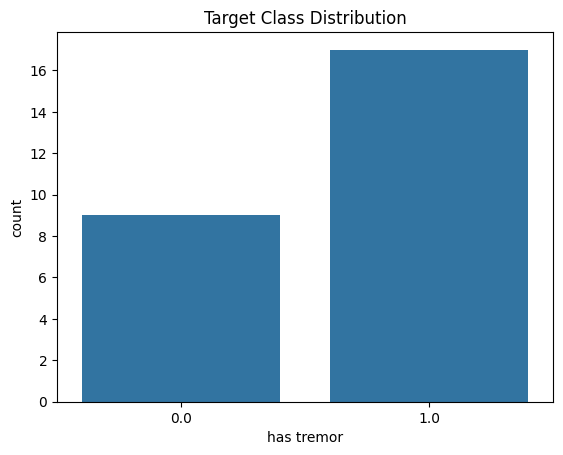

```python
# Check imbalance of the dataset
sns.countplot(data=df_no_outliers, x=target_col)
plt.title("Target Class Distribution")
```

```python
df_no_outliers[target_col].value_counts(normalize=True)
```

```
has tremor
1.0    0.653846
0.0    0.346154
Name: proportion, dtype: float64
```

We can see that the target label distribution is quite imbalanced

**4. Check the distribution of tremor features across target values**

```python
def boxplotdis(df, x_value, y_value1, title1, x_label, y_label1, y_value2, title2, y_label2):
    # Create subplots
    fig, axes = plt.subplots(1, 2, figsize=(12, 6))  # 1 row, 2 columns

    # First box plot
    sns.boxplot(x=x_value, y=y_value1, data=df, ax=axes[0])
    axes[0].set_title(title1)
    axes[0].set_xlabel(x_label)
    axes[0].set_ylabel(y_label1)

    # Second box plot
    sns.boxplot(x=x_value, y=y_value2, data=df, ax=axes[1])
    axes[1].set_title(title2)
    axes[1].set_xlabel(x_label)
    axes[1].set_ylabel(y_label2)

    # Adjust layout
    plt.tight_layout()
    plt.show()
```

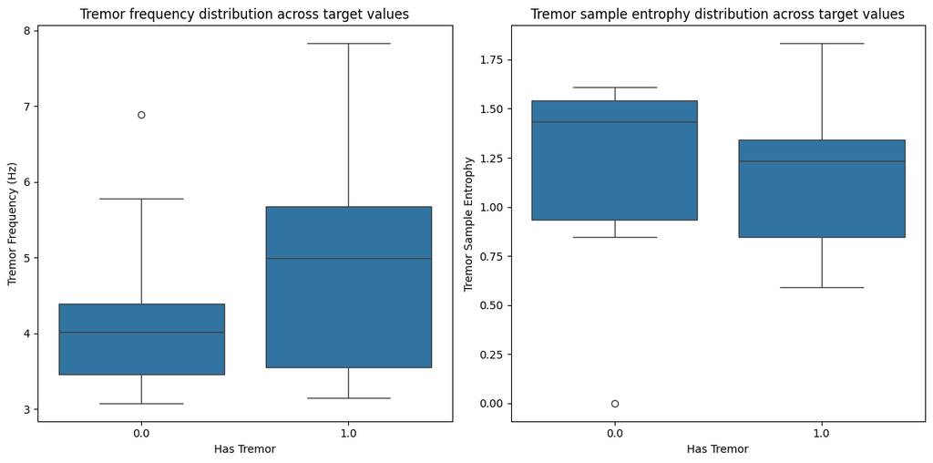

```python
# Check outliers in the feature data
boxplotdis(df_no_outliers, target_col,'tremor_freq', "Tremor frequency distribution across target values", "Has Tremor", "Tremor Frequency (Hz)", 'tremor_sample_entropy', "Tremor sample entrophy distribution across target values", "Tremor Sample Entrophy")
```

- Tremor frequency: There is higher median frequency in positive class, suggesting tremor frequency tends to be higher in groups (participant id, medication, side) has tremor
- Tremor sample entrophy: In tremor (1.0) group, median entropy is lower (~1.2). This indicates tremor segments are more regular, periodic.

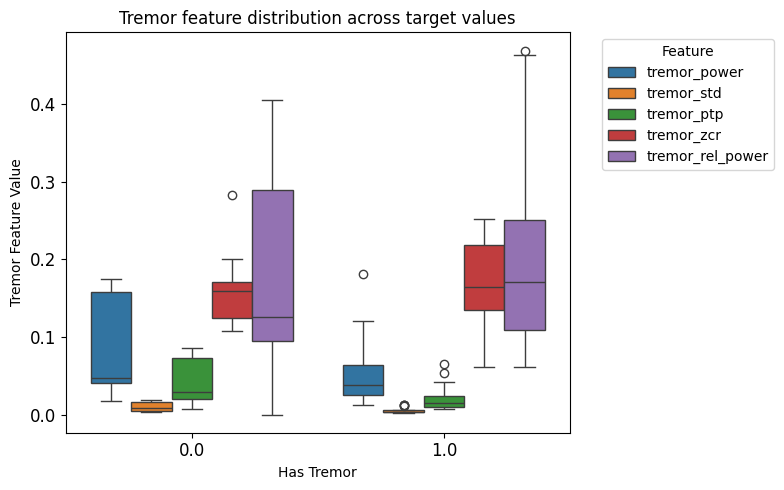

```python
columns_of_interest = ['tremor_power', 'tremor_std', 'tremor_ptp', 'tremor_zcr', 'tremor_rel_power']

# Check outliers in the feature data
drawBoxPlot(df_no_outliers, columns_of_interest,target_col, False, "Tremor feature distribution across target values", "Has Tremor", "Tremor Feature Value")
```

**5. Check the distribution of tremor features across medication values**

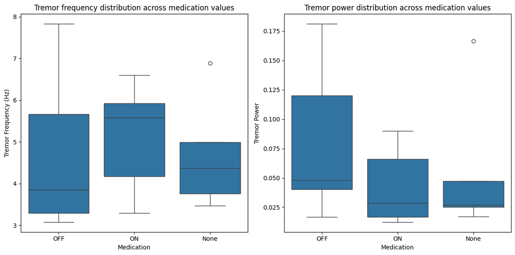

```python
# Check outliers in the feature data
boxplotdis(df_no_outliers, 'medication','tremor_freq', "Tremor frequency distribution across medication values", "Medication", "Tremor Frequency (Hz)", 'tremor_power', "Tremor power distribution across medication values", "Tremor Power")
```

OFF Medication:

- Tremor power has the highest spread. The median is higher than ON and None. There is more variability in tremor power. This may reveal that tremor tends to be stronger and more variable when patients are off medication
- Tremor frequency is lower on average, with a median around 3.8 Hz. However, there's a wide spread, indicating more variability.

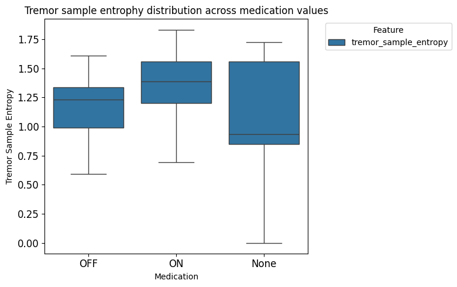

```python
columns_of_interest = ['tremor_sample_entropy']

# Check outliers in the feature data
drawBoxPlot(df_no_outliers, columns_of_interest,'medication', False, "Tremor sample entrophy distribution across medication values", "Medication", "Tremor Sample Entropy")
```

OFF Medication: Lower entropy suggests the signal is more predictable or regular, reflecting consistent tremor patterns.

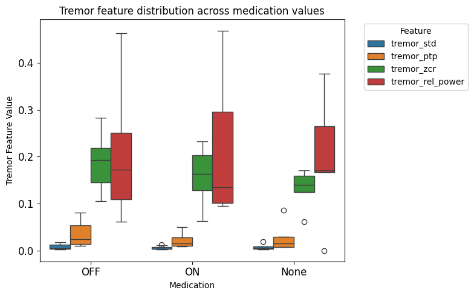

```python
columns_of_interest = ['tremor_std', 'tremor_ptp', 'tremor_zcr', 'tremor_rel_power']

# Check outliers in the feature data
drawBoxPlot(df_no_outliers, columns_of_interest,'medication', False, "Tremor feature distribution across medication values", "Medication", "Tremor Feature Value")
```

**6. Perform statistical tests to check for significant differences between groups regarding the features**

```python
# Perform statistical tests to check for significant differences between groups regarding the features
from scipy.stats import ttest_ind, mannwhitneyu, shapiro
import pandas as pd

# Split data into tremor and no tremor
group_0 = df_no_outliers[df_no_outliers[target_col] == 0.0]
group_1 = df_no_outliers[df_no_outliers[target_col] == 1.0]

# let check tremor_std and tremor_ptp to see if we need to remove them from the dataset.
features = ['tremor_std', 'tremor_ptp']

results = []

for feature in features:
    data0 = group_0[feature].dropna()
    data1 = group_1[feature].dropna()

    # Test for normality
    stat0, p0 = shapiro(data0)
    stat1, p1 = shapiro(data1)

    normal = p0 > 0.05 and p1 > 0.05

    if normal:
        stat, p_value = ttest_ind(data0, data1)
        test_type = 't-test'
    else:
        stat, p_value = mannwhitneyu(data0, data1)
        test_type = 'Mann-Whitney U'

    results.append({
        'feature': feature,
        'test_used': test_type,
        'p_value': p_value
    })

# Show results in DataFrame
results_df = pd.DataFrame(results)
print(results_df.sort_values(by='p_value'))
```

```
      feature       test_used   p_value
0  tremor_std  Mann-Whitney U  0.031094
1  tremor_ptp  Mann-Whitney U  0.131271
```

- p_value of tremor_std < 0.05 means that this feature shows significant difference between the 2 groups so it should be kept
- p_value of tremore_ptp > 0.05 so we should remove this feature from the dataset

```python
def stratified_split_by_participant_fixed(df, target_col, participant_col, test_size=0.2, random_state=42):

    # Aggregate target column by participant
    participant_target = df.groupby(participant_col)[target_col].apply(lambda x: 1 if (x == 1).any() else 0).reset_index()
    participant_target.rename(columns={target_col: 'has_target'}, inplace=True)

    # Stratified split on participants
    train_participants, test_participants = train_test_split(
        participant_target[participant_col],
        test_size=test_size,
        stratify=participant_target['has_target'],
        random_state=random_state
    )

    # Filter the original dataset based on the split
    train_data = df[df[participant_col].isin(train_participants)]
    test_data = df[df[participant_col].isin(test_participants)]

    # Verify proportions
    print("Train set proportions and count:")
    print(train_data[target_col].value_counts(normalize=True), train_data[target_col].value_counts())

    print("Test set proportions and count:")
    print(test_data[target_col].value_counts(normalize=True), test_data[target_col].value_counts())

    return train_data, test_data
```

**7. Split dataset into train and test set by participants to avoid data leakage**

```python
train_data, test_data = stratified_split_by_participant_fixed(
    df_no_outliers,
    target_col=target_col,
    participant_col='participant id',
    test_size=0.2,
    random_state=42
)
```

```
Train set proportions and count:
has tremor
1.0    0.666667
0.0    0.333333
Name: proportion, dtype: float64 has tremor
1.0    14
0.0     7
Name: count, dtype: int64
Test set proportions and count:
has tremor
1.0    0.6
0.0    0.4
Name: proportion, dtype: float64 has tremor
1.0    3
0.0    2
Name: count, dtype: int64
```

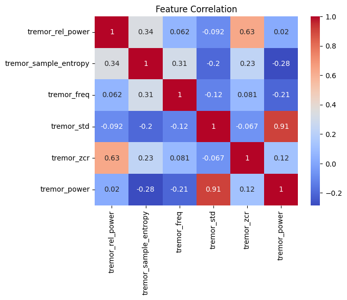

```python
# Check feature correlation
columns_of_interest = ['tremor_rel_power', 'tremor_sample_entropy', 'tremor_freq', 'tremor_std', 'tremor_zcr', 'tremor_power']
correlation_matrix = df_no_outliers[columns_of_interest].corr()
sns.heatmap(correlation_matrix, annot=True, cmap="coolwarm")
plt.title("Feature Correlation")
plt.show()
```

We can see that: tremor_power is highly correlated with tremor_std, we can remove 1 of them, let remove tremor_std

```python
columns_of_interest = ['tremor_rel_power', 'tremor_zcr', 'tremor_sample_entropy', 'tremor_freq', 'tremor_power']

X_train = train_data[columns_of_interest]
X_test = test_data[columns_of_interest]

y_train = train_data[target_col]
y_test = test_data[target_col]
```

```python
def plot_roc_curve(y_true, y_scores):
    from sklearn.metrics import roc_curve, auc
    fpr, tpr, thresholds = roc_curve(y_true, y_scores)
    roc_auc = auc(fpr, tpr)

    plt.figure(figsize=(8, 6))
    plt.plot(fpr, tpr, color='blue', lw=2, label=f'ROC curve (area = {roc_auc:.2f})')
    plt.plot([0, 1], [0, 1], color='red', lw=2, linestyle='--')
    plt.xlim([0.0, 1.0])
    plt.ylim([0.0, 1.05])
    plt.xlabel('False Positive Rate')
    plt.ylabel('True Positive Rate')
    plt.title('Receiver Operating Characteristic (ROC) Curve')
    plt.legend(loc='lower right')
    plt.grid()
    plt.show()
```

```python
from sklearn.ensemble import RandomForestClassifier
# from sklearn.model_selection import LeaveOneGroupOut

def trainUseLOGORandomForest(train_data, X_train, y_train):
    groups_train = train_data['participant id']

    logo = LeaveOneGroupOut()

    y_true, y_pred = [], []
    y_prob = []

    for train_idx, val_idx in logo.split(X_train, y_train, groups=groups_train):
        # Raw splits
        X_t_raw, X_v_raw = X_train.iloc[train_idx], X_train.iloc[val_idx]
        y_t, y_v = y_train.iloc[train_idx], y_train.iloc[val_idx]

        # Train model
        model = RandomForestClassifier(
            n_estimators=100,        # Number of trees
            max_depth=3,             # Limit depth to prevent overfitting
            class_weight='balanced', # Adjust for class imbalance
            random_state=42
        )

        model.fit(X_t_raw, y_t)
        y_pred_raw = model.predict(X_v_raw)
        y_prob_raw = model.predict_proba(X_v_raw)[:, 1]  # For ROC AUC

        y_pred.extend(y_pred_raw)
        y_true.extend(y_v)
        y_prob.extend(y_prob_raw)

    # Evaluation
    print("Leave-One-Group-Out CV Classification Report for Random Forest:")
    # print(classification_report(y_true, y_pred))

    precision = metrics.precision_score(y_true, y_pred)
    recall = metrics.recall_score(y_true, y_pred)
    f1 = metrics.f1_score(y_true, y_pred)
    accuracy = accuracy_score(y_true, y_pred)
    print(f"Accuracy: {accuracy:.1%}")
    print(f"Precision: {precision:.1%}")
    print(f"Recall: {recall:.1%}")
    print(f"F1 Score: {f1:.1%}")

    plot_roc_curve(y_true, y_prob)
```

```python
# Final train on all of X_train
def evalTestSetRandomForest(X_train, X_test, y_test, y_train):

    model_final = RandomForestClassifier(
        n_estimators=100,        # Number of trees
        max_depth=3,             # Limit depth to prevent overfitting
        min_samples_split=5, # Minimum samples to split an internal node
        class_weight='balanced', # Adjust for class imbalance
        random_state=42
    )

    model_final.fit(X_train, y_train)
    y_test_pred = model_final.predict(X_test)

    # Predict on same training data
    y_train_pred = model_final.predict(X_train)
    print("Performance on the whole training set:")
    precision = metrics.precision_score(y_train, y_train_pred)
    recall = metrics.recall_score(y_train, y_train_pred)
    f1 = metrics.f1_score(y_train, y_train_pred)
    accuracy = accuracy_score(y_train, y_train_pred)
    print(f"Accuracy: {accuracy:.1%}")
    print(f"Precision: {precision:.1%}")
    print(f"Recall: {recall:.1%}")
    print(f"F1 Score: {f1:.1%}")
    # print(classification_report(y_train, y_train_pred))

    # Final evaluation
    print("\nPerformance on the whole test set:")
    # print(classification_report(y_test, y_test_pred, zero_division=0))

    precision = metrics.precision_score(y_test, y_test_pred)
    recall = metrics.recall_score(y_test, y_test_pred)
    f1 = metrics.f1_score(y_test, y_test_pred)
    accuracy = accuracy_score(y_test, y_test_pred)
    print(f"Accuracy: {accuracy:.1%}")
    print(f"Precision: {precision:.1%}")
    print(f"Recall: {recall:.1%}")
    print(f"F1 Score: {f1:.1%}")

    disp = ConfusionMatrixDisplay.from_predictions(
        y_test,
        y_test_pred,
        cmap=plt.cm.Blues,
        normalize=None  # Use None for unnormalized counts;
    )

    plt.title("Confusion Matrix")
    plt.show()

    # Get predicted probabilities
    print("\nROC Curve on test set:")
    y_proba = model_final.predict_proba(X_test)[:, 1]  # probability of class 1
    plot_roc_curve(y_test, y_proba)
```

```python
def trainUseLOGOLogisticRegression(train_data, X_train, y_train):
    groups_train = train_data['participant id']

    logoLR = LeaveOneGroupOut()

    y_true_all, y_pred_all = [], []
    y_prob_all = []

    for train_idx, val_idx in logoLR.split(X_train, y_train, groups=groups_train):

        # Raw splits
        X_train_raw, X_val_raw = X_train.iloc[train_idx], X_train.iloc[val_idx]
        y_train_raw, y_val_raw = y_train.iloc[train_idx], y_train.iloc[val_idx]

        # Fit scaler only on training data
        scaler = StandardScaler()
        X_train_scaled = scaler.fit_transform(X_train_raw)
        X_test_scaled = scaler.transform(X_val_raw)  # Use same scaler

        # Train model
        model = LogisticRegression(
            # multi_class='ovr',
            solver='lbfgs',
            class_weight='balanced',  # helpful for imbalanced classes
            max_iter=1000,
            random_state=42
        )


        model.fit(X_train_scaled, y_train_raw)
        y_pred = model.predict(X_test_scaled)
        y_prob = model.predict_proba(X_test_scaled)[:, 1]  # For ROC AUC

        y_pred_all.extend(y_pred)
        y_true_all.extend(y_val_raw)
        y_prob_all.extend(y_prob)

    # Evaluation
    print("Leave-One-Group-Out CV Classification Report for Logistic Regression:")
    # print(classification_report(y_true, y_true))
    precision = metrics.precision_score(y_true_all, y_pred_all)
    recall = metrics.recall_score(y_true_all, y_pred_all)
    f1 = metrics.f1_score(y_true_all, y_pred_all)
    accuracy = accuracy_score(y_true_all, y_pred_all)
    print(f"Accuracy: {accuracy:.1%}")
    print(f"Precision: {precision:.1%}")
    print(f"Recall: {recall:.1%}")
    print(f"F1 Score: {f1:.1%}")

    plot_roc_curve(y_true_all, y_prob_all)
```

```python
# Final train on all of X_train
def evalTestSetLogisticRegression(X_train, X_test, y_test, y_train):

    model_final = LogisticRegression(
        # multi_class='ovr',
        solver='lbfgs',
        class_weight='balanced',  # helpful for imbalanced classes
        max_iter=1000,
        random_state=42
    )

    model_final.fit(X_train, y_train)
    y_test_pred = model_final.predict(X_test)

    # Predict on same training data
    y_train_pred = model_final.predict(X_train)
    print("Performance on the whole training set:")
    precision = metrics.precision_score(y_train, y_train_pred)
    recall = metrics.recall_score(y_train, y_train_pred)
    f1 = metrics.f1_score(y_train, y_train_pred)
    accuracy = accuracy_score(y_train, y_train_pred)
    print(f"Accuracy: {accuracy:.1%}")
    print(f"Precision: {precision:.1%}")
    print(f"Recall: {recall:.1%}")
    print(f"F1 Score: {f1:.1%}")
    # print(classification_report(y_train, y_train_pred))

    # Final evaluation
    print("\nPerformance on the whole test set:")
    # print(classification_report(y_test, y_test_pred, zero_division=0))

    precision = metrics.precision_score(y_test, y_test_pred)
    recall = metrics.recall_score(y_test, y_test_pred)
    f1 = metrics.f1_score(y_test, y_test_pred)
    accuracy = accuracy_score(y_test, y_test_pred)
    print(f"Accuracy: {accuracy:.1%}")
    print(f"Precision: {precision:.1%}")
    print(f"Recall: {recall:.1%}")
    print(f"F1 Score: {f1:.1%}")

    disp = ConfusionMatrixDisplay.from_predictions(
        y_test,
        y_test_pred,
        cmap=plt.cm.Blues,
        normalize=None  # Use None for unnormalized counts;
    )

    plt.title("Confusion Matrix")
    plt.show()

    # Get predicted probabilities
    print("\nROC Curve on test set:")
    y_proba = model_final.predict_proba(X_test)[:, 1]  # probability of class 1
    plot_roc_curve(y_test, y_proba)
```

**Training and evaluating model**

```
Leave-One-Group-Out CV Classification Report for Random Forest:
Accuracy: 52.4%
Precision: 62.5%
Recall: 71.4%
F1 Score: 66.7%
```

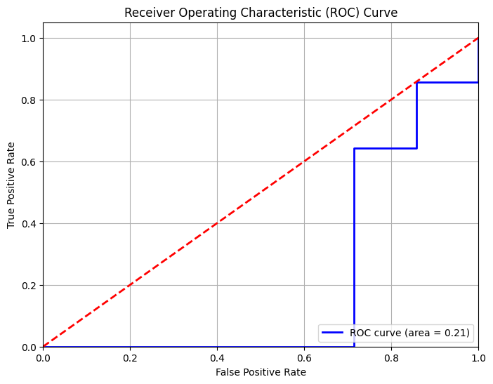

```python
trainUseLOGORandomForest(train_data, X_train, y_train)
```

```
Performance on the whole training set:
Accuracy: 100.0%
Precision: 100.0%
Recall: 100.0%
F1 Score: 100.0%

Performance on the whole test set:
Accuracy: 80.0%
Precision: 75.0%
Recall: 100.0%
F1 Score: 85.7%
```

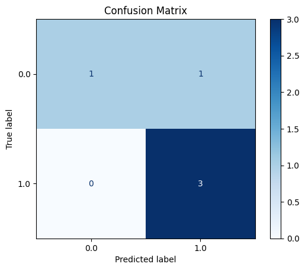

```
ROC Curve on test set:
```

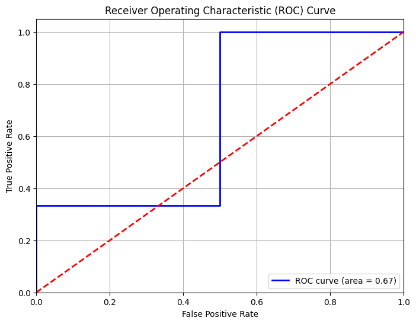

```python
evalTestSetRandomForest(X_train, X_test, y_test, y_train)
```

Observation: AUC is 0.67 means that it has moderate ability to separate classes on the test set. Training performance is too well (100% at all metrics) indicates the model has memorized the data. The gap regarding performance between training set and test set is quite large (20%) which means model was overfitting.

```
Leave-One-Group-Out CV Classification Report for Logistic Regression:
Accuracy: 52.4%
Precision: 64.3%
Recall: 64.3%
F1 Score: 64.3%
```

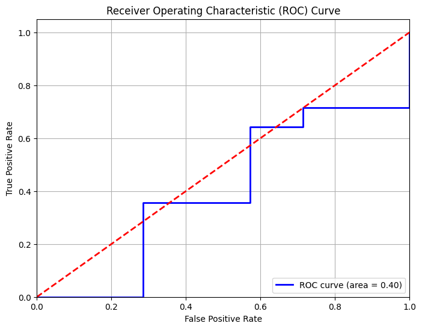

```
Performance on the whole training set:
Accuracy: 57.1%
Precision: 77.8%
Recall: 50.0%
F1 Score: 60.9%

Performance on the whole test set:
Accuracy: 60.0%
Precision: 66.7%
Recall: 66.7%
F1 Score: 66.7%
```

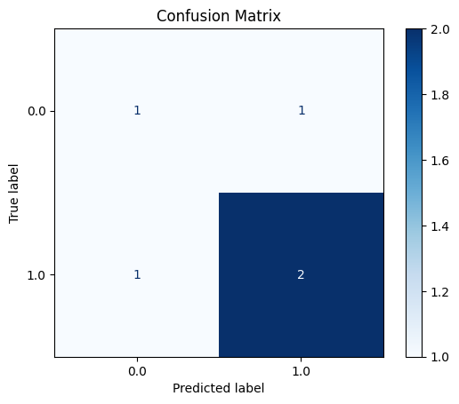

```
ROC Curve on test set:
```

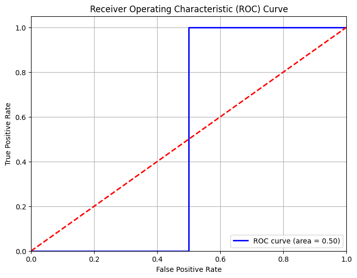

```python
trainUseLOGOLogisticRegression(train_data, X_train, y_train)
evalTestSetLogisticRegression(X_train, X_test, y_test, y_train)
```

Training and test performance are similar to each other confirms no overfitting but still not a good performance. AUC = 0.5 shows that the model is performing no better than random guessing.